# hw5

Austin Melendez

2025-10-09

#### The following was completed for the STAT 140A - Homework 5 assignment.

# Homework 5

## Using the sat dataset, fit a model with the total SAT score as the response and expend, salary, ratio and takers as predictors.

### 6.1) Perform regression diagnostics on this model to answer the following questions. Display any plots that are relevant.

```r
#install.packages("faraway")
library(faraway)

data(sat)

model <- lm(total ~ expend + salary + ratio + takers, data = sat)

summary(model)
```

```
##
## Call:
## lm(formula = total ~ expend + salary + ratio + takers, data = sat)
##
## Residuals:
##     Min      1Q  Median      3Q     Max
## -90.531 -20.855  -1.746  15.979  66.571
##
## Coefficients:
##              Estimate Std. Error t value Pr(>|t|)
## (Intercept) 1045.9715    52.8698  19.784  < 2e-16 ***
## expend         4.4626    10.5465   0.423    0.674
## salary         1.6379     2.3872   0.686    0.496
## ratio         -3.6242     3.2154  -1.127    0.266
## takers        -2.9045     0.2313 -12.559 2.61e-16 ***
## ---
## Signif. codes:  0 '***' 0.001 '**' 0.01 '*' 0.05 '.' 0.1 ' ' 1
##
## Residual standard error: 32.7 on 45 degrees of freedom
## Multiple R-squared:  0.8246, Adjusted R-squared:  0.809
## F-statistic: 52.88 on 4 and 45 DF,  p-value: < 2.2e-16
```

#### A) Lets check our model assumptions to verify the model is useful. First, let’s check the constant variance assumption, we’ll test for homoscedasticity.

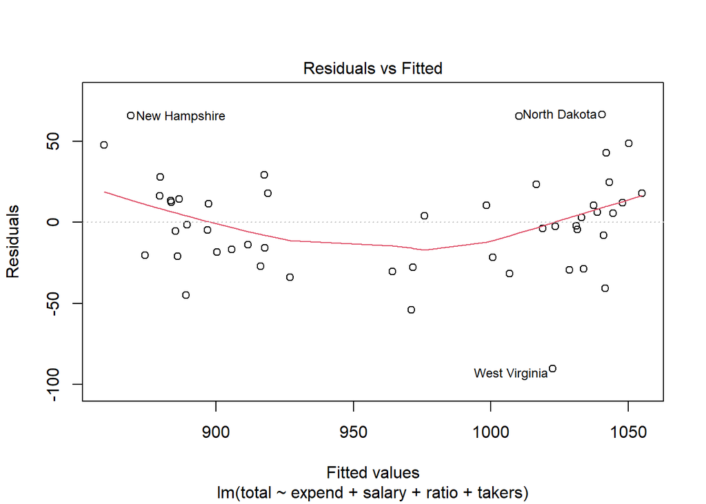

```r
plot(model, which = 1)
```

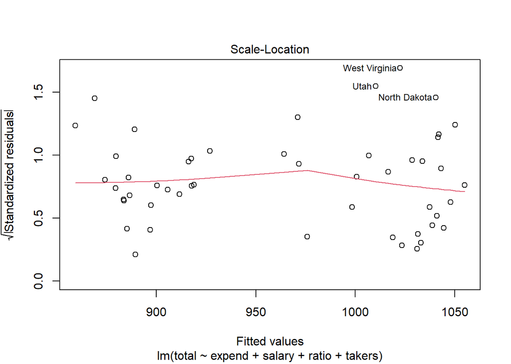

```r
plot(model, which = 3)
```

The data shows some possible mild heteroscedasticity, but not a large influence. The residuals vs fitted graph shows some points we may want to investigate further such as `West Virginia`, `North Dakota`, and `New Hampshire`.

#### B) Next lets check the normality assumption.

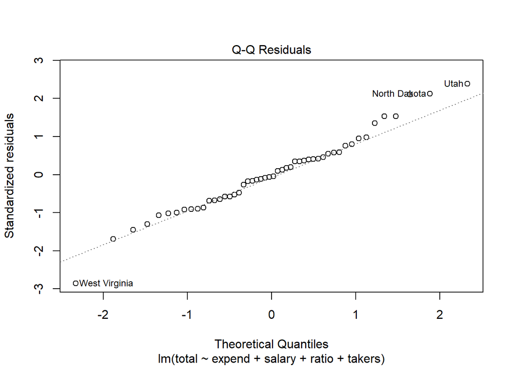

```r
plot(model, which = 2)
```

Looking at the Q-Q plot, some the majority of our data is on the line. However, it could be argued the the extreme ends of the data ends with tailing values. Based on this graph, `West virginia` is definitely a point to investigate further.

#### C) Lets take a closer look at some high leverage points.

```r
hatv <- hatvalues(model)

print(hatv)
```

```
##        Alabama         Alaska        Arizona       Arkansas     California
##     0.09537668     0.18030612     0.04931612     0.05382878     0.28211791
##       Colorado    Connecticut       Delaware        Florida        Georgia
##     0.03014533     0.22545191     0.05823786     0.14068586     0.09418039
##         Hawaii          Idaho       Illinois        Indiana           Iowa
##     0.05164378     0.05847998     0.13483540     0.05031937     0.05882595
##         Kansas       Kentucky      Louisiana          Maine       Maryland
##     0.10383439     0.04106460     0.08754545     0.13973600     0.05372121
##  Massachusetts       Michigan      Minnesota    Mississippi       Missouri
##     0.08871286     0.16536832     0.06069775     0.06245712     0.05589831
##        Montana       Nebraska         Nevada  New Hampshire     New Jersey
##     0.12118024     0.07953981     0.04539029     0.08283540     0.22209778
##     New Mexico       New York North Carolina   North Dakota           Ohio
##     0.04533550     0.19157520     0.09063656     0.08104629     0.04477728
##       Oklahoma         Oregon   Pennsylvania   Rhode Island South Carolina
##     0.05949338     0.09828873     0.12277229     0.06739042     0.09671590
##   South Dakota      Tennessee          Texas           Utah        Vermont
##     0.09658262     0.09162128     0.05405622     0.29211280     0.08566501
##       Virginia     Washington  West Virginia      Wisconsin        Wyoming
##     0.15230581     0.10816994     0.06206536     0.09807708     0.08748135
```

```r
sum(hatv)
```

```
## [1] 5
```

#### D) Let’s check for outliers!

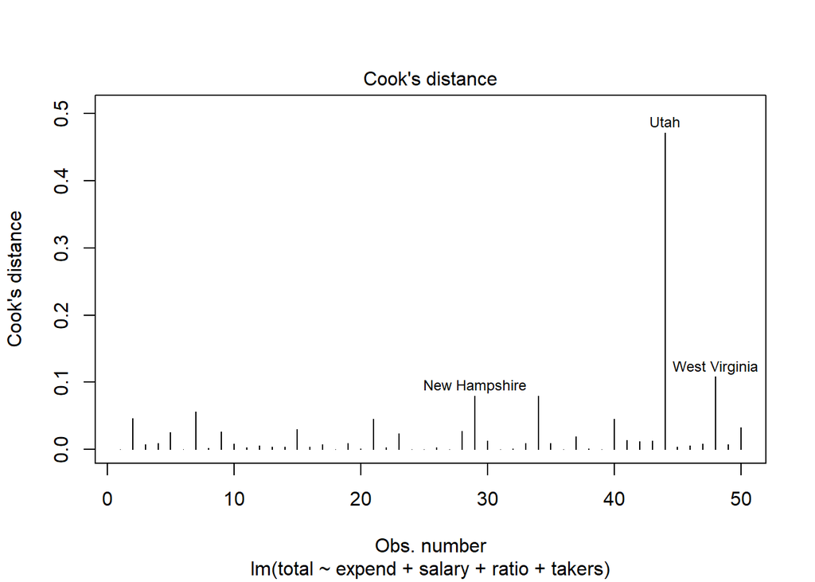

```r
plot(model, which = 4)
```

```r
which(abs(rstandard(model)) > 2)
```

```
## New Hampshire  North Dakota          Utah West Virginia
##            29            34            44            48
```

This shows us that there are four states that exceed $\pm2$ standard deviations. These four states are `New Hampshire`, `North Dakota`, `Utah`, and `West Virginia`.

#### E) Influential points?

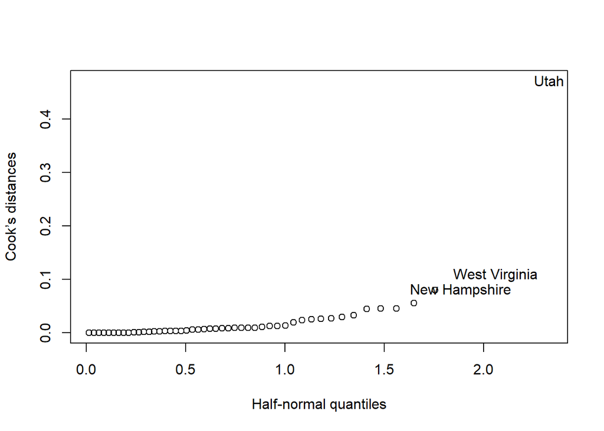

```r
states <- row.names(sat)

cook <- cooks.distance(model)

halfnorm(cook,3,labs=states,ylab="Cook’s distances")
```

`West Virginia`, `New Hampshire`, and `Utah` have high cook’s distances with high half-normal quantiles. So let’s remove the highest value, `Utah`, from the model to see if the model improves.

#### F) Model Structure?

```r
model_reduced <- lm(total ~ expend + salary + ratio + takers,
                    data = subset(sat, rownames(sat) != "Utah"))

summary(model_reduced)
```

```
##
## Call:
## lm(formula = total ~ expend + salary + ratio + takers, data = subset(sat,
##     rownames(sat) != "Utah"))
##
## Residuals:
##     Min      1Q  Median      3Q     Max
## -92.118 -18.402   1.808  14.890  67.669
##
## Coefficients:
##              Estimate Std. Error t value Pr(>|t|)
## (Intercept) 1093.8460    53.4226  20.475   <2e-16 ***
## expend        -0.9427    10.1922  -0.092    0.927
## salary         3.0964     2.3283   1.330    0.190
## ratio         -7.6391     3.4279  -2.229    0.031 *
## takers        -2.9308     0.2188 -13.397   <2e-16 ***
## ---
## Signif. codes:  0 '***' 0.001 '**' 0.01 '*' 0.05 '.' 0.1 ' ' 1
##
## Residual standard error: 30.9 on 44 degrees of freedom
## Multiple R-squared:  0.8396, Adjusted R-squared:  0.825
## F-statistic: 57.58 on 4 and 44 DF,  p-value: < 2.2e-16
```

### 6.2) sing the teengamb dataset answer the following questions.

```r
data(teengamb)

model2 <- lm(gamble ~ sex + status + income + verbal, data = teengamb)

summary(model2)
```

```
##
## Call:
## lm(formula = gamble ~ sex + status + income + verbal, data = teengamb)
##
## Residuals:
##     Min      1Q  Median      3Q     Max
## -51.082 -11.320  -1.451   9.452  94.252
##
## Coefficients:
##              Estimate Std. Error t value Pr(>|t|)
## (Intercept)  22.55565   17.19680   1.312   0.1968
## sex         -22.11833    8.21111  -2.694   0.0101 *
## status        0.05223    0.28111   0.186   0.8535
## income        4.96198    1.02539   4.839 1.79e-05 ***
## verbal       -2.95949    2.17215  -1.362   0.1803
## ---
## Signif. codes:  0 '***' 0.001 '**' 0.01 '*' 0.05 '.' 0.1 ' ' 1
##
## Residual standard error: 22.69 on 42 degrees of freedom
## Multiple R-squared:  0.5267, Adjusted R-squared:  0.4816
## F-statistic: 11.69 on 4 and 42 DF,  p-value: 1.815e-06
```

#### A) Lets check our model assumptions to verify the model is useful. First, let’s check the constant variance assumption, we’ll test for homoscedasticity.

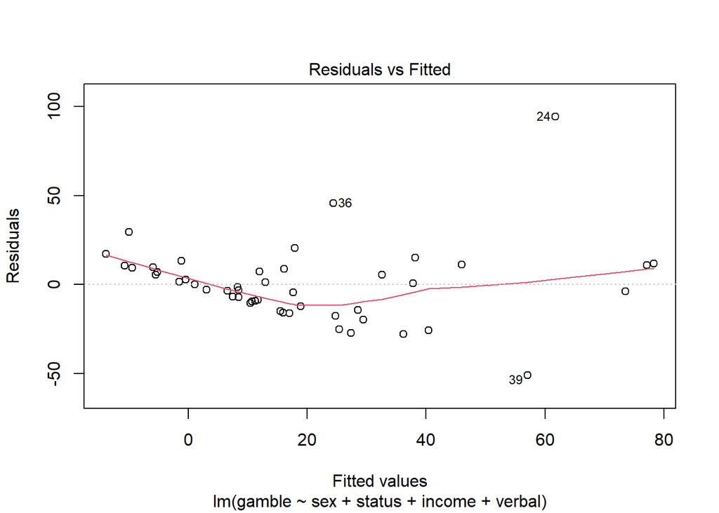

```r
plot(model2, which = 1)
```

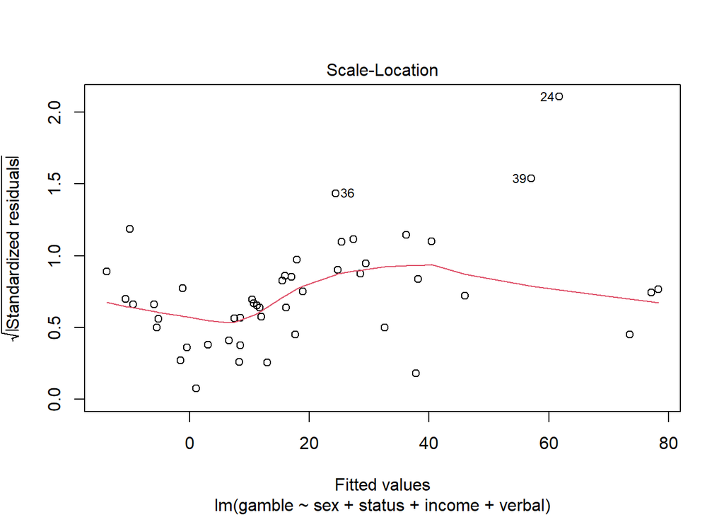

```r
plot(model2, which = 3)
```

The data definitely shows heteroscedasticity and possibly non-linearity. The residuals vs fitted graph shows an obvious cone of points that increases distances as you go through the data.

#### B) Next lets check the normality assumption.

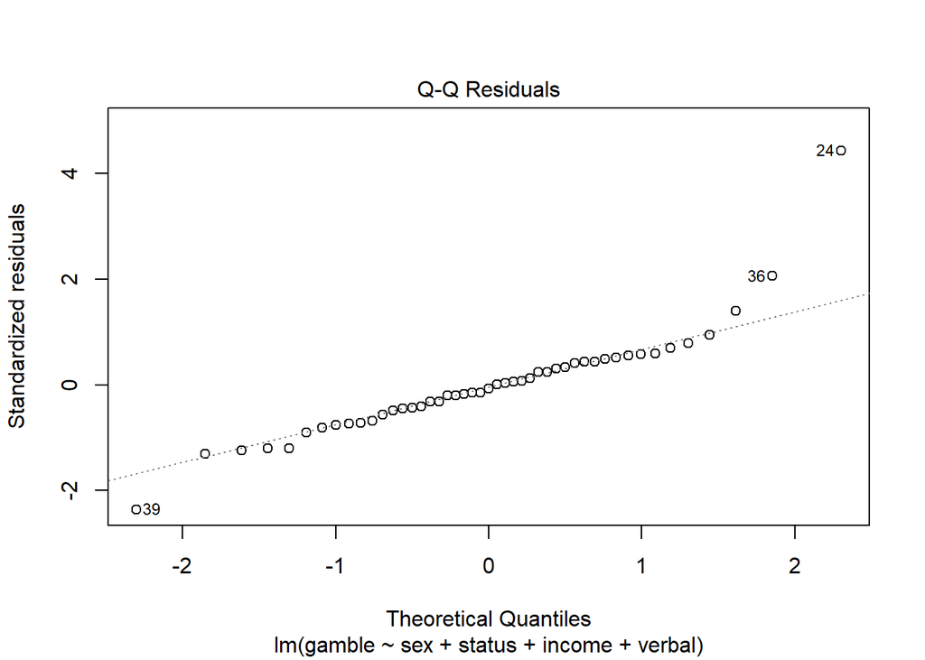

```r
plot(model2, which = 2)
```

Looking at the Q-Q plot, some the majority of our data is on the line. However, the the extreme ends of the data ends with tailing values. Based on this graph, points `24`, `36`, and `39` are definitely points to investigate further.

#### C) Lets take a closer look at some high leverage points.

```r
hatv2 <- hatvalues(model2)

print(hatv2)
```

```
##          1          2          3          4          5          6          7
## 0.07988226 0.10851291 0.06347643 0.10273955 0.13866946 0.16378563 0.06893316
##          8          9         10         11         12         13         14
## 0.07110422 0.07051619 0.10871017 0.10096045 0.07004982 0.10529294 0.07363771
##         15         16         17         18         19         20         21
## 0.05826146 0.08372118 0.14000342 0.11994753 0.06905872 0.08776687 0.05010691
##         22         23         24         25         26         27         28
## 0.11496664 0.06693234 0.12380463 0.10273229 0.11229428 0.10583404 0.11010633
##         29         30         31         32         33         34         35
## 0.07729898 0.05145946 0.23950314 0.10677583 0.22134389 0.10707672 0.31180294
##         36         37         38         39         40         41         42
## 0.04659071 0.08212433 0.09761361 0.09155208 0.08739786 0.11648008 0.30160877
##         43         44         45         46         47
## 0.08715765 0.06897428 0.06737462 0.08718333 0.07887418
```

```r
sum(hatv2)
```

```
## [1] 5
```

#### D) Let’s check for outliers!

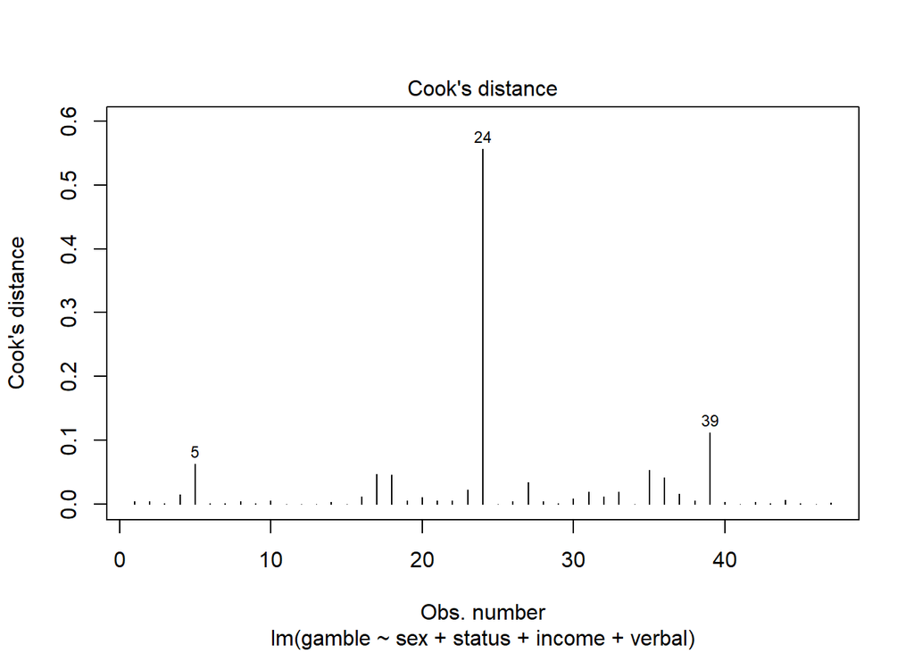

```r
plot(model2, which = 4)
```

```r
which(abs(rstandard(model2)) > 2)
```

```
## 24 36 39
## 24 36 39
```

This shows us that there are three points that exceed $\pm2$ standard deviations. These three points are `24`, `36`, and `39`.

#### E) Influential points?

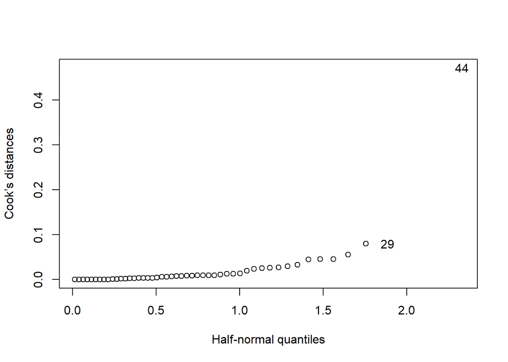

```r
index <- row.names(teengamb)

cook2 <- cooks.distance(model2)

halfnorm(cook,3,labs=index,ylab="Cook’s distances")
```

#### F) Model Structure?

```r
model_reduced2 <- lm(gamble ~ sex + status + income + verbal, data = subset(teengamb, rownames(teengamb) != "24"))

summary(model_reduced2)
```

```
##
## Call:
## lm(formula = gamble ~ sex + status + income + verbal, data = subset(teengamb,
##     rownames(teengamb) != "24"))
##
## Residuals:
##     Min      1Q  Median      3Q     Max
## -42.999  -8.102  -0.491   8.600  46.688
##
## Coefficients:
##             Estimate Std. Error t value Pr(>|t|)
## (Intercept)   7.6306    12.9251   0.590   0.5582
## sex         -16.2986     6.1335  -2.657   0.0112 *
## status        0.1739     0.2083   0.835   0.4088
## income        4.3312     0.7636   5.672 1.26e-06 ***
## verbal       -1.8019     1.6137  -1.117   0.2707
## ---
## Signif. codes:  0 '***' 0.001 '**' 0.01 '*' 0.05 '.' 0.1 ' ' 1
##
## Residual standard error: 16.74 on 41 degrees of freedom
## Multiple R-squared:  0.5682, Adjusted R-squared:  0.526
## F-statistic: 13.49 on 4 and 41 DF,  p-value: 4.225e-07
```

### 7.3) Using the divusa data:

#### A) it a regression model with divorce as the response and unemployed, femlab, marriage, birth and military as predictors.

```r
data(divusa)

model3 <- lm(divorce ~ unemployed + femlab + marriage + birth + military, data = divusa)
summary(model3)
```

```
##
## Call:
## lm(formula = divorce ~ unemployed + femlab + marriage + birth +
##     military, data = divusa)
##
## Residuals:
##     Min      1Q  Median      3Q     Max
## -3.8611 -0.8916 -0.0496  0.8650  3.8300
##
## Coefficients:
##             Estimate Std. Error t value Pr(>|t|)
## (Intercept)  2.48784    3.39378   0.733   0.4659
## unemployed  -0.11125    0.05592  -1.989   0.0505 .
## femlab       0.38365    0.03059  12.543  < 2e-16 ***
## marriage     0.11867    0.02441   4.861 6.77e-06 ***
## birth       -0.12996    0.01560  -8.333 4.03e-12 ***
## military    -0.02673    0.01425  -1.876   0.0647 .
## ---
## Signif. codes:  0 '***' 0.001 '**' 0.01 '*' 0.05 '.' 0.1 ' ' 1
##
## Residual standard error: 1.65 on 71 degrees of freedom
## Multiple R-squared:  0.9208, Adjusted R-squared:  0.9152
## F-statistic: 165.1 on 5 and 71 DF,  p-value: < 2.2e-16
```

```r
kappa(model3, exact = TRUE)
```

```
## [1] 2228.957
```

A high condition number indicates that some predictors are highly linearly related coefficients may be unstable and standard errors inflated.

#### B) Compute VIFs

```r
vif(model3)
```

```
## unemployed     femlab   marriage      birth   military
##   2.252888   3.613276   2.864864   2.585485   1.249596
```

The VIF’s show us there is low multicollinerarity.

```r
model3_reduced <- lm(divorce ~ unemployed + femlab + marriage, data = divusa)

summary(model3_reduced)
```

```
##
## Call:
## lm(formula = divorce ~ unemployed + femlab + marriage, data = divusa)
##
## Residuals:
##     Min      1Q  Median      3Q     Max
## -3.5076 -1.6993 -0.3501  1.5951  5.4775
##
## Coefficients:
##              Estimate Std. Error t value Pr(>|t|)
## (Intercept) -12.91474    3.93157  -3.285  0.00157 **
## unemployed    0.12270    0.06694   1.833  0.07089 .
## femlab        0.50863    0.03656  13.911  < 2e-16 ***
## marriage      0.07784    0.03290   2.366  0.02064 *
## ---
## Signif. codes:  0 '***' 0.001 '**' 0.01 '*' 0.05 '.' 0.1 ' ' 1
##
## Residual standard error: 2.302 on 73 degrees of freedom
## Multiple R-squared:  0.8416, Adjusted R-squared:  0.8351
## F-statistic: 129.3 on 3 and 73 DF,  p-value: < 2.2e-16
```

```r
vif(model3_reduced)
```

```
## unemployed     femlab   marriage
##   1.658646   2.653361   2.673478
```

```r
kappa(model3_reduced, exact = TRUE)
```

```
## [1] 1248.79
```

The VIF’s have decreased so the collinearity has be en reduced.

### 9.2) he cornnit data on the relationship between corn `yield` (bushels per acre) and `nitrogen` (pounds per acre) fertilizer application.

```r
data(cornnit)

model4 <- lm(yield ~ nitrogen, data = cornnit)

summary(model4)
```

```
##
## Call:
## lm(formula = yield ~ nitrogen, data = cornnit)
##
## Residuals:
##     Min      1Q  Median      3Q     Max
## -60.439 -10.939   1.534  14.082  29.697
##
## Coefficients:
##              Estimate Std. Error t value Pr(>|t|)
## (Intercept) 107.43864    4.66622   23.02  < 2e-16 ***
## nitrogen      0.17730    0.03377    5.25 4.71e-06 ***
## ---
## Signif. codes:  0 '***' 0.001 '**' 0.01 '*' 0.05 '.' 0.1 ' ' 1
##
## Residual standard error: 20.53 on 42 degrees of freedom
## Multiple R-squared:  0.3962, Adjusted R-squared:  0.3818
## F-statistic: 27.56 on 1 and 42 DF,  p-value: 4.713e-06
```

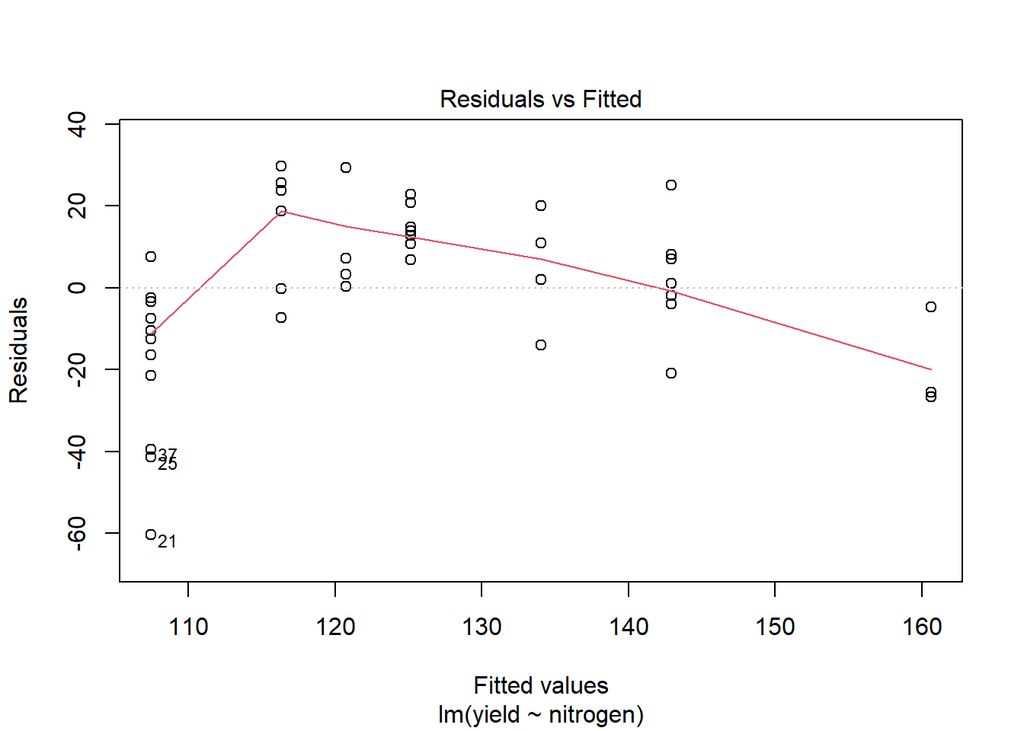

```r
plot(model4, which = 1)
```

This shows a slight non-linear pattern that we will have to investigate further.

Let’s try some different common transformations.

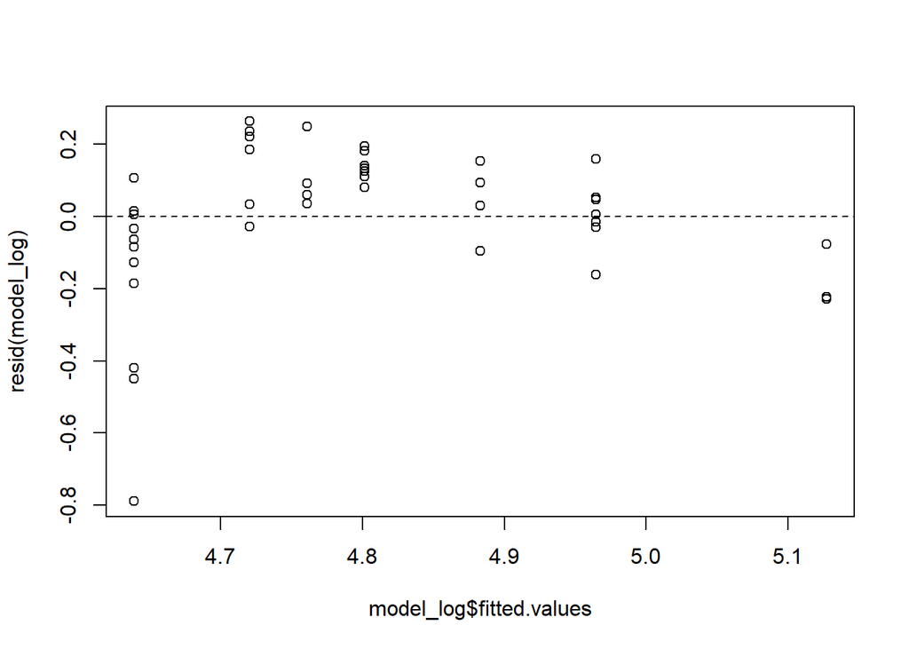

```r
model_log <- lm(log(yield) ~ nitrogen, data=cornnit)
plot(model_log$fitted.values, resid(model_log))

abline(h=0, lty=2)
```

```r
model_sqrt <- lm(sqrt(yield) ~ nitrogen, data=cornnit)

model_quad <- lm(yield ~ nitrogen + I(nitrogen^2), data=cornnit)

summary(model_quad)
```

```
##
## Call:
## lm(formula = yield ~ nitrogen + I(nitrogen^2), data = cornnit)
##
## Residuals:
##     Min      1Q  Median      3Q     Max
## -47.162  -7.092   0.368  10.058  26.571
##
## Coefficients:
##                 Estimate Std. Error t value Pr(>|t|)
## (Intercept)   94.1620969  4.4067757  21.368  < 2e-16 ***
## nitrogen       0.5794901  0.0800285   7.241 7.54e-09 ***
## I(nitrogen^2) -0.0014831  0.0002787  -5.321 3.97e-06 ***
## ---
## Signif. codes:  0 '***' 0.001 '**' 0.01 '*' 0.05 '.' 0.1 ' ' 1
##
## Residual standard error: 15.98 on 41 degrees of freedom
## Multiple R-squared:  0.6428, Adjusted R-squared:  0.6254
## F-statistic:  36.9 on 2 and 41 DF,  p-value: 6.817e-10
```

Let’s compare the goodness of fit for our transformed models.

```r
anova(model4, model_quad)
```

```
## Analysis of Variance Table
##
## Model 1: yield ~ nitrogen
## Model 2: yield ~ nitrogen + I(nitrogen^2)
##   Res.Df   RSS Df Sum of Sq      F    Pr(>F)
## 1     42 17699
## 2     41 10470  1    7229.6 28.312 3.974e-06 ***
## ---
## Signif. codes:  0 '***' 0.001 '**' 0.01 '*' 0.05 '.' 0.1 ' ' 1
```

```r
summary(model_quad)
```

```
##
## Call:
## lm(formula = yield ~ nitrogen + I(nitrogen^2), data = cornnit)
##
## Residuals:
##     Min      1Q  Median      3Q     Max
## -47.162  -7.092   0.368  10.058  26.571
##
## Coefficients:
##                 Estimate Std. Error t value Pr(>|t|)
## (Intercept)   94.1620969  4.4067757  21.368  < 2e-16 ***
## nitrogen       0.5794901  0.0800285   7.241 7.54e-09 ***
## I(nitrogen^2) -0.0014831  0.0002787  -5.321 3.97e-06 ***
## ---
## Signif. codes:  0 '***' 0.001 '**' 0.01 '*' 0.05 '.' 0.1 ' ' 1
##
## Residual standard error: 15.98 on 41 degrees of freedom
## Multiple R-squared:  0.6428, Adjusted R-squared:  0.6254
## F-statistic:  36.9 on 2 and 41 DF,  p-value: 6.817e-10
```

Lastly, lets do a Box-Cox to automatically find the optimal transformation.

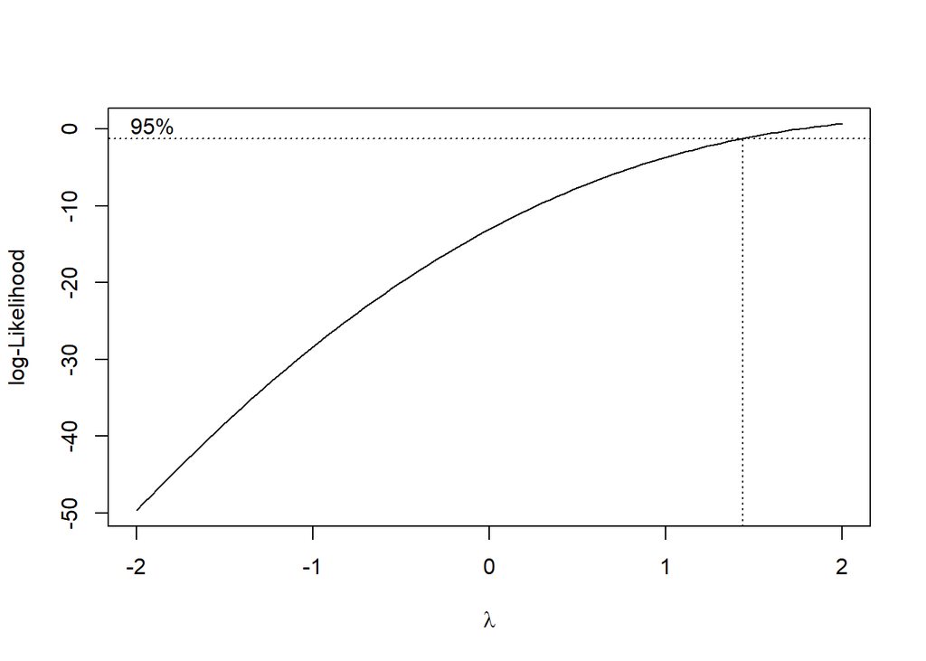

```r
library(MASS)
boxcox(model4, lambda = seq(-2, 2, 0.1))
```

### 9.3 Using the ozone data, fit a model with `O3` as the response and `temp`, `humidity` and `ibh` as predictors. Use the Box–Cox method to determine the best transformation on the response.

```r
data(ozone)

model_oz <- lm(O3 ~ temp + humidity + ibh, data=ozone)

summary(model_oz)
```

```
##
## Call:
## lm(formula = O3 ~ temp + humidity + ibh, data = ozone)
##
## Residuals:
##      Min       1Q   Median       3Q      Max
## -11.5291  -3.0137  -0.2249   2.8239  13.9303
##
## Coefficients:
##               Estimate Std. Error t value Pr(>|t|)
## (Intercept) -1.049e+01  1.616e+00  -6.492 3.16e-10 ***
## temp         3.296e-01  2.109e-02  15.626  < 2e-16 ***
## humidity     7.738e-02  1.339e-02   5.777 1.77e-08 ***
## ibh         -1.004e-03  1.639e-04  -6.130 2.54e-09 ***
## ---
## Signif. codes:  0 '***' 0.001 '**' 0.01 '*' 0.05 '.' 0.1 ' ' 1
##
## Residual standard error: 4.524 on 326 degrees of freedom
## Multiple R-squared:  0.684,  Adjusted R-squared:  0.6811
## F-statistic: 235.2 on 3 and 326 DF,  p-value: < 2.2e-16
```

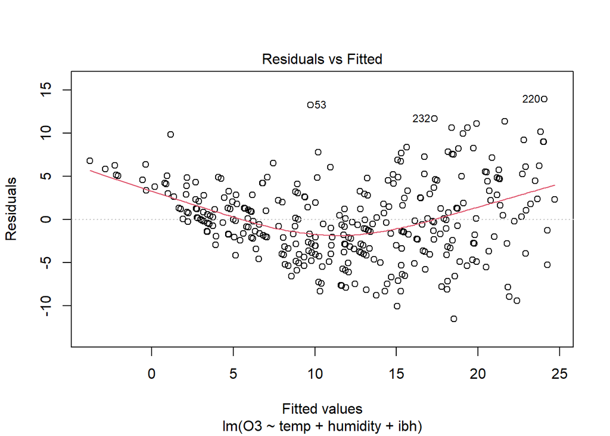

```r
plot(model_oz, which = 1)
```

The residuals vs fitted plot indicates non-constant variance, we will need to transform this data to fix it.

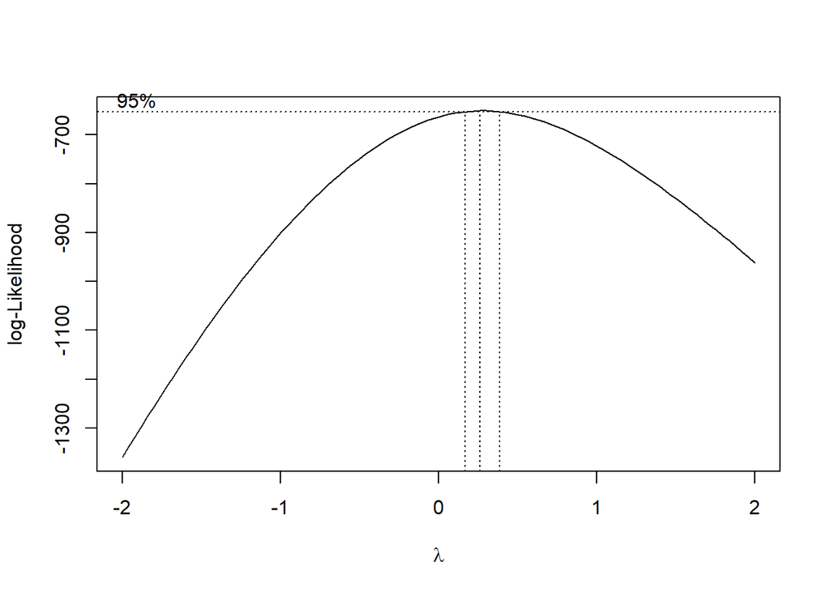

```r
boxcox(model_oz, lambda = seq(-2, 2, 0.1))
```

```r
model_oz_log <- lm(log(O3) ~ temp + humidity + ibh, data=ozone)

summary(model_oz_log)
```

```
##
## Call:
## lm(formula = log(O3) ~ temp + humidity + ibh, data = ozone)
##
## Residuals:
##      Min       1Q   Median       3Q      Max
## -1.54457 -0.25991  0.03967  0.27841  1.19747
##
## Coefficients:
##               Estimate Std. Error t value Pr(>|t|)
## (Intercept)  3.101e-01  1.477e-01   2.099   0.0366 *
## temp         2.966e-02  1.928e-03  15.386  < 2e-16 ***
## humidity     6.392e-03  1.224e-03   5.222 3.16e-07 ***
## ibh         -1.168e-04  1.497e-05  -7.796 8.66e-14 ***
## ---
## Signif. codes:  0 '***' 0.001 '**' 0.01 '*' 0.05 '.' 0.1 ' ' 1
##
## Residual standard error: 0.4135 on 326 degrees of freedom
## Multiple R-squared:  0.6975, Adjusted R-squared:  0.6948
## F-statistic: 250.6 on 3 and 326 DF,  p-value: < 2.2e-16
```